# Gaussian Processes

May 19, 2020

## Scope of talk

- **Motivating example :)**
- **Some facts about Guassian Distributions**
- **Gaussian Processes - core**
- **Application 1 - Regression**
- **Application 2 - Hyper parameter optimization**

## Example - nonlinear regression without ‘certainty’ estimation

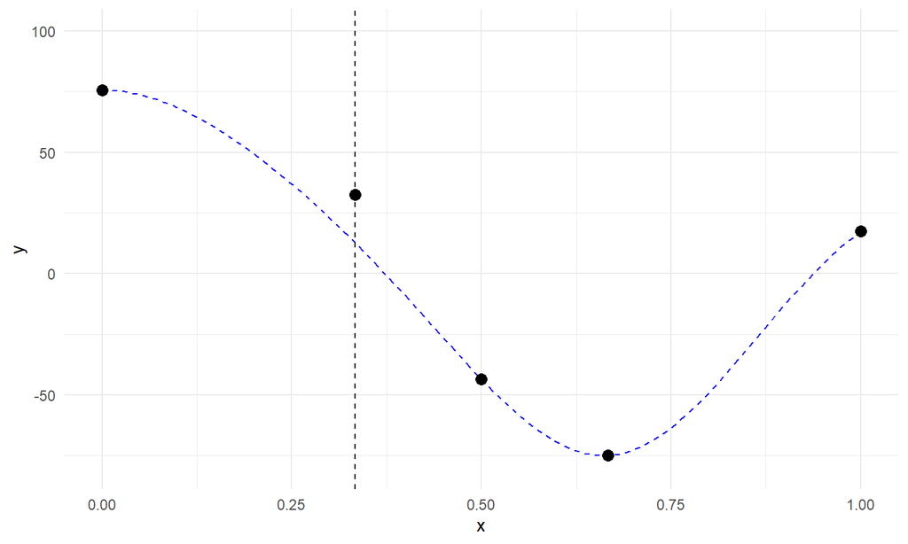

## Example - nonlinear regression WITH ‘certainty’ estimation

- Nonlinear regression based on black points - estimation for the red one:

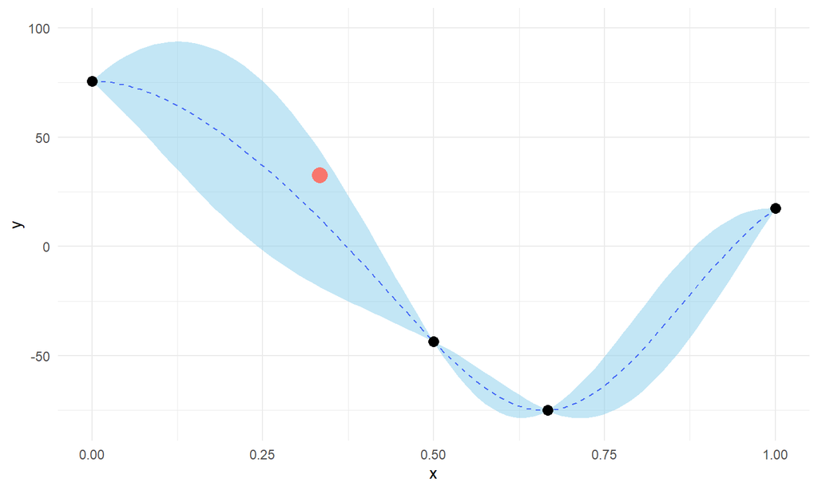

## Gaussians

## 1 dimensional Gaussisn

We have: \(\ X \sim \mathcal{N}(\mu,\,\sigma^{2})\) - two parameters mean and sd, with density given by: \(f(x) = \frac{1}{{\sigma \sqrt {2\pi } }}e^{{{ - \left( {x - \mu } \right)^2 } \mathord{\left/ {\vphantom {{ - \left( {x - \mu } \right)^2 } {2\sigma ^2 }}} \right. } {2\sigma ^2 }}}\)

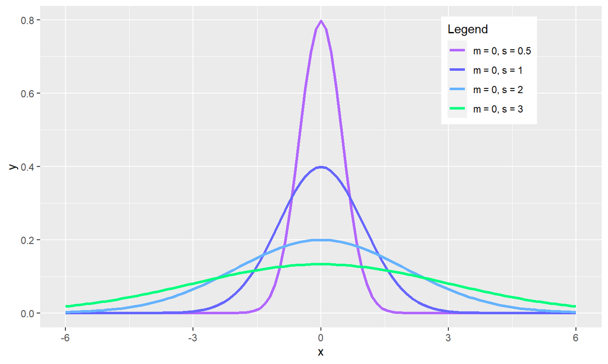

## Multi dimensional Gaussisn

We write: \(\ X \sim \mathcal{N}(\mu,\,\Sigma)\) ,\(\begin{equation*} \Sigma = \begin{pmatrix} \sigma_{1,1} & \cdots & \sigma_{1,n} \\ \ddots \\ \sigma_{n,1} & \cdots & \sigma_{n,n} \end{pmatrix} \end{equation*}\) , \(\begin{equation*} \mu = \begin{pmatrix} \mu_{1} \\ \ddots \\ \mu_{n} \end{pmatrix} \end{equation*}\) for a multivariate Gaussian dist’ with Cov matrix and Mean vector.

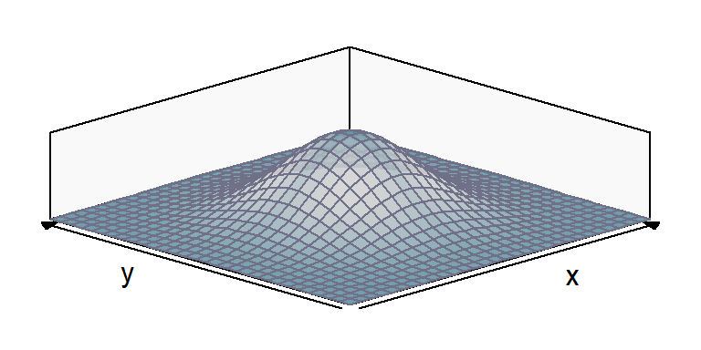

we can write: \(X=\begin{pmatrix} x_A\\ x_B \end{pmatrix}\), \(\mu=\begin{pmatrix} \mu_A\\\mu_B\end{pmatrix}\) and \(\Sigma=\begin{pmatrix} \Sigma_{AA} & \Sigma_{AB} \\ \Sigma_{BA} & \Sigma_{BB} \end{pmatrix}\)

## 2 dim Gaussian examples:

Having: \(\ X \sim \mathcal{N}(\mu,\,\Sigma)\) with \(\mu=\left[\begin{array} {rrr} 0 \\ 0 \\ \end{array}\right]\) , \(\mathbf{\Sigma} = \left(\begin{array} {rrr} \sigma_1 &\rho \\ \rho & \sigma_2 \end{array}\right)\), some examples of effect of sigma and rho on shape:

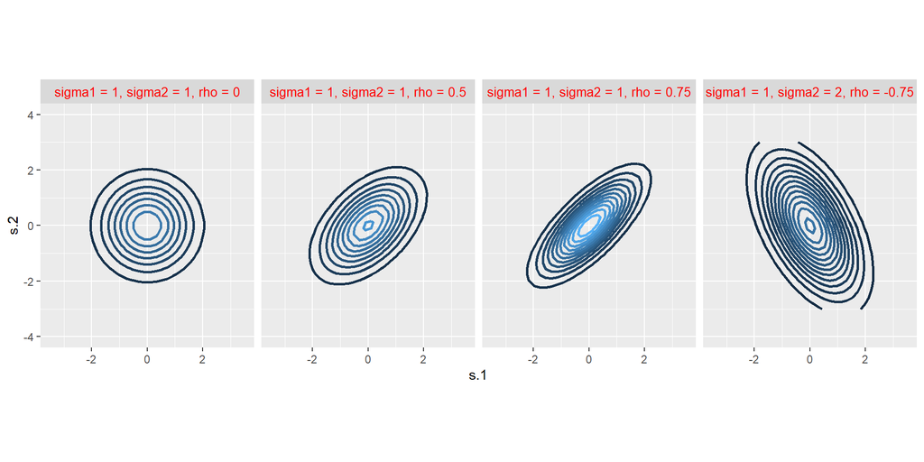

## Marginalization property:

We have: \(\;p(x) = \int p(x, y)dy\;\) for the Marginal probability density.  
What about the multivariate Gaussian ?  
(can two marginal Gaussians ‘come’ from non jointly Gaussian ??)…

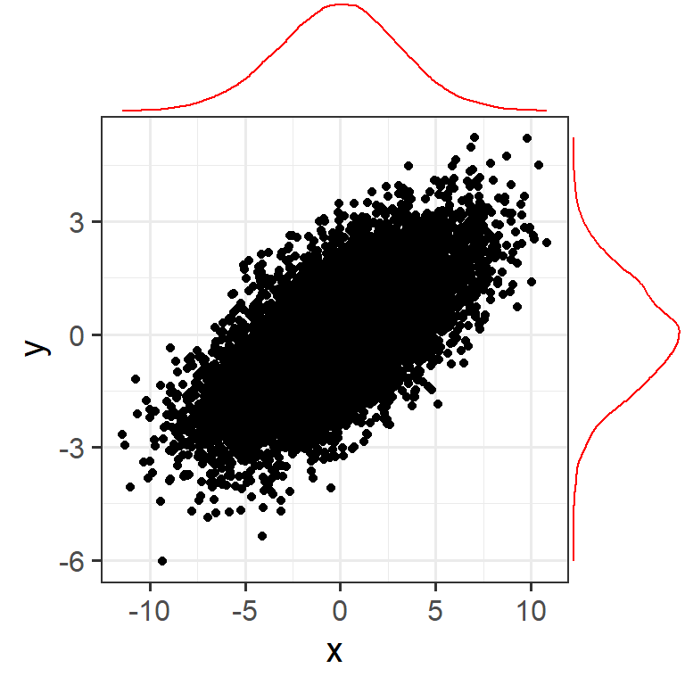

## And with formulas - Marginals:

When we have multivariate Gaussian partitioned into: \(x=\begin{pmatrix} x_A\\ x_B \end{pmatrix}\),  
with mean: \(\mu=\begin{pmatrix} \mu_A\\\mu_B\end{pmatrix}\) and cov matrix: \(\Sigma=\begin{pmatrix} \Sigma_{AA} & \Sigma_{AB} \\ \Sigma_{BA} & \Sigma_{BB} \end{pmatrix}\), we have  
marginal densities \(p(x_A)=\int_{x_B}p(x_A,x_B;\mu,\Sigma)dx_B\) and  
\(p(x_B)=\int_{x_A}p(x_A,x_B;\mu,\Sigma)dx_A\) Gaussians with:  
\(\boxed{\color{blue}{x_A \sim \mathcal{N}(\mu_A,\,\Sigma_{AA}) , x_B \sim \mathcal{N}(\mu_B,\,\Sigma_{BB})}}\)

## Marginalization property - Cont’:

Can two marginal Gaussians ‘come’ from non jointly Gaussian? - Yes !

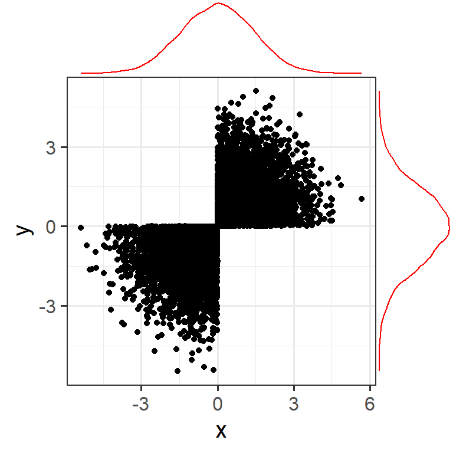

## Conditioning property:

What’s the case for two Gaussians when we condition on one ? …

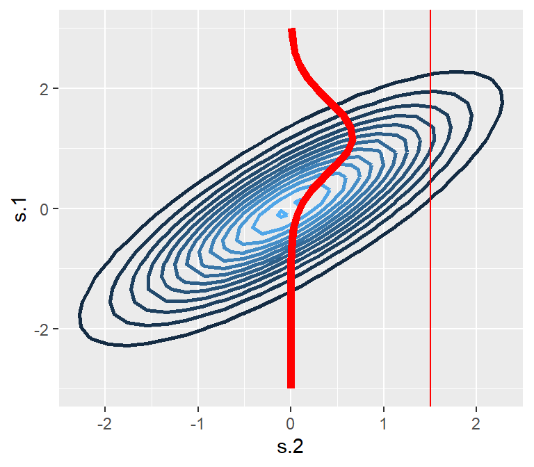

[output not shown]

## And with formulas - Conditional:

Again for our multivariate Gaussian : \(x=\begin{pmatrix} x_A\\ x_B \end{pmatrix}\),  
with mean: \(\mu=\begin{pmatrix} \mu_A\\\mu_B\end{pmatrix}\) and cov matrix: \(\Sigma=\begin{pmatrix} \Sigma_{AA} & \Sigma_{AB} \\ \Sigma_{BA} & \Sigma_{BB} \end{pmatrix}\),  
We have conditional density: \(\ p(x_A\mid x_B)=\frac{p(x_A,x_B;\mu,\Sigma)}{\int_{x_A}p(x_A,x_B;\mu,\Sigma)dx_A}\)  
a Gaussian with:  
\(\boxed{\color{blue}{x_A\mid x_B \sim \mathcal{N}(\mu_A+\Sigma_{AB}\Sigma_{BB}^{-1}(x_B-\mu_B) , \Sigma_{AA}-\Sigma_{AB}\Sigma_{BB}^{-1}\Sigma_{BA})}}\)  
and similar for \(x_B\mid x_A\) and \(p(x_B\mid x_A)\)

## From Gaussians to Gaussian Processes

## Gaussian Process - Definition

A **Gaussian Process** is a collection of indexed random variables  
(RV’s) (i.e by time where index set is \(\mathbb{R}\) ) such that  
every finite collection of those RV’s has a multivariate normal distribution  
\(\color{blue}{f(x) \sim \mathcal{GP}(m(x),k(x,x'))}\) , meaning for any finite subset \(X =\{\mathbf{x}_1 \ldots \mathbf{x}_n \}\)  
of the domain x we have: \(f(X) \sim \mathcal{N}(m(X), k(X, X))\) with  
mean vector: \(\mathbf{\mu} = m(X)\) and cov matrix \(\Sigma = k(X, X)\) -  
called - the Kernel

## Gaussian Process - example:

Let’s take the following Gussian kernel : \(\operatorname{k}(x_i, x_j) = \exp\left(-\frac{(x_i - x_j)^2}{2 \ell ^ 2}\right)\) with different \(\ell\) values - the index set to be 50 equidistant points in -5 to 5 (‘time series’).

* The closer the points, \(x_1,x_2\)  
the more correlated the samples  
for fixed \(\ell\)  
* The higher the \(\ell\)  
the larger kernel values  
for fixed two points

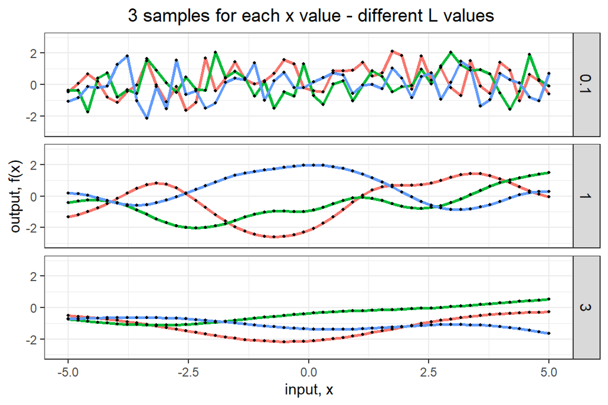

## Different Kernels:

**Alot of Kernels exist out there:**  
Exponential quadratic: \(\ k(x_a, x_b) = \sigma^2 \exp \left(-\frac{ \left\Vert x_a - x_b \right\Vert^2}{2\ell^2}\right)\)  
Rational quadratic: \(\ k(x_a, x_b) = \sigma^2 \left( 1 + \frac{ \left\Vert x_a - x_b \right\Vert^2}{2 \alpha \ell^2} \right)^{-\alpha}\)  
Periodic: \(\ k(x_a, x_b) = \sigma^2 \exp \left(-\frac{2}{\ell^2}\sin^2 \left( \pi \frac{\lvert x_a - x_b \rvert}{p}\right) \right)\)  
*A lot others also as Kernels can be combined by adding them together

## Kernel example - Periodic:

\(\ k(x_a, x_b) = \sigma^2 \exp \left(-\frac{2}{\ell^2}\sin^2 \left( \pi \frac{\lvert x_a - x_b \rvert}{p}\right) \right),\ell=1,\sigma=1\)

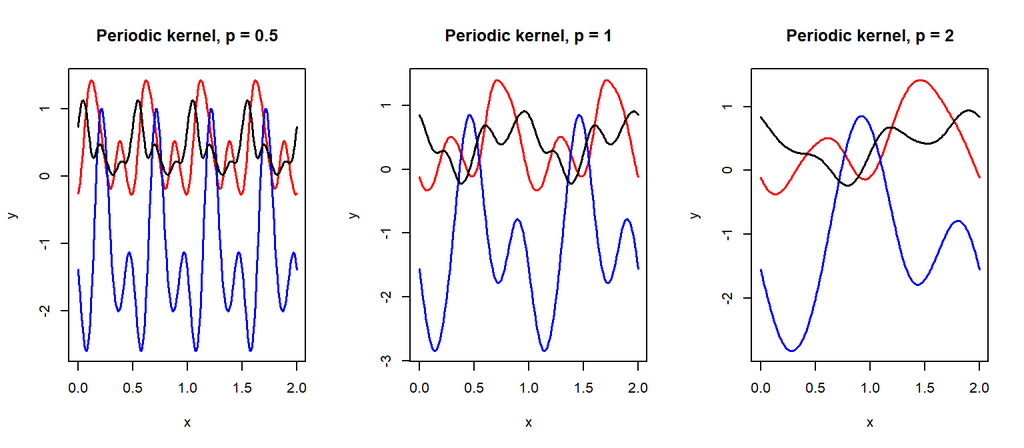

## Gaussian Process Regression

## Gaussian Process - making prediction:

In order to make prediction using GP we use the equation from before: \(\boxed{\color{blue}{x_A\mid x_B \sim \mathcal{N}(\mu_A+\Sigma_{AB}\Sigma_{BB}^{-1}(x_B-\mu_B) , \Sigma_{AA}-\Sigma_{AB}\Sigma_{BB}^{-1}\Sigma_{BA})}}\)

so if we decompose \(\Sigma\) as \(\begin{pmatrix} K, K_* \\K_*^\top , K_{**} \end{pmatrix}\) with \(K\) the training kernel matrix,  
\(K_*\) the training-testing kernel matrix, and \(K_{**}\) testing kernel matrix,  
the conditional distribution of (noise free) values of test function \(f_*\) ,given  
\(\ Y,X\) the training and \(\ X_*\) our test points are (taking mean = 0) dist’:  
\(f_*|(Y,X,X_* )\sim \mathcal{N}(K_*^\top K^{-1}y,K_{**}-K_*^\top K^{-1}K_*)\)  
*additional version for noisy data as well

## Example for prediction - noise free training data:

Looking at \(k(\mathbf{x}_i,\mathbf{x}_j) = \sigma_f^2 \exp(-\frac{1}{2l^2} (\mathbf{x}_i - \mathbf{x}_j)^T (\mathbf{x}_i - \mathbf{x}_j))\) - the Gaussian/exponential kernel, and training data: \((-4,-1) ,\ (-3,0.5),\ (-2,1),\ (0,1.5),\ (1,-1)\) , we use the posterior dist’:

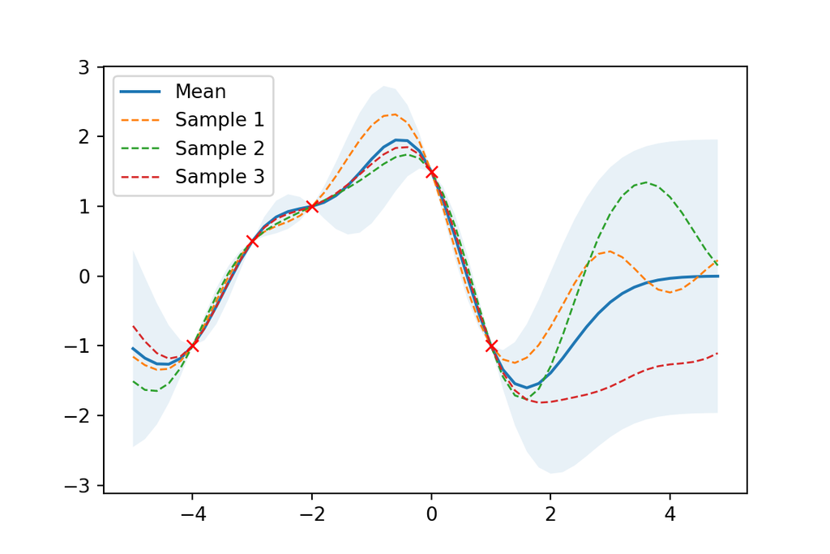

## Example for prediction - noisy training data:

In case some noise is included and we only get approximated training points so non-zero variance at those points:

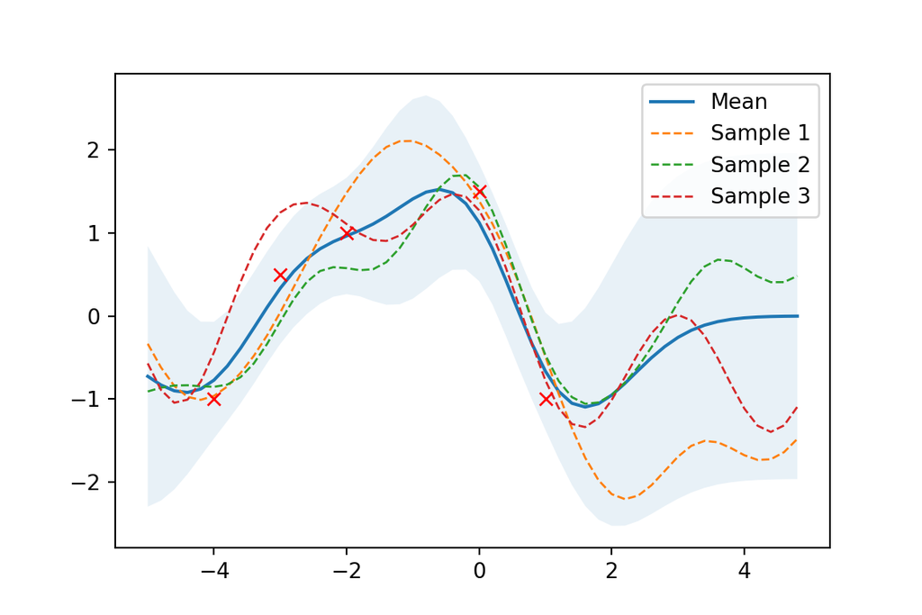

## The effect of kernel’s parameters:

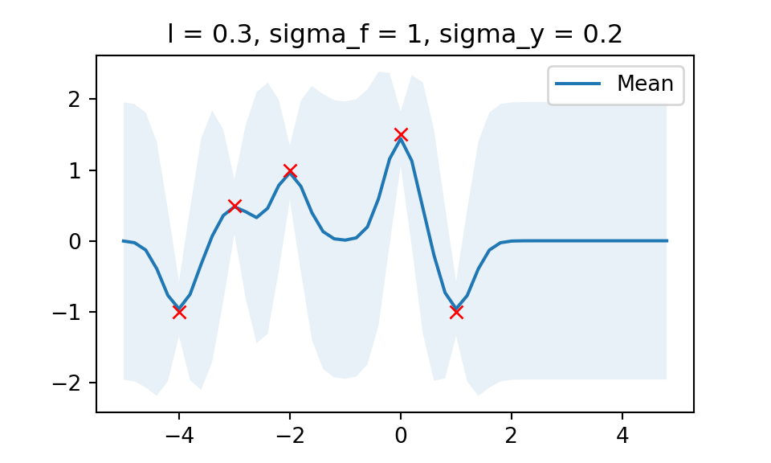

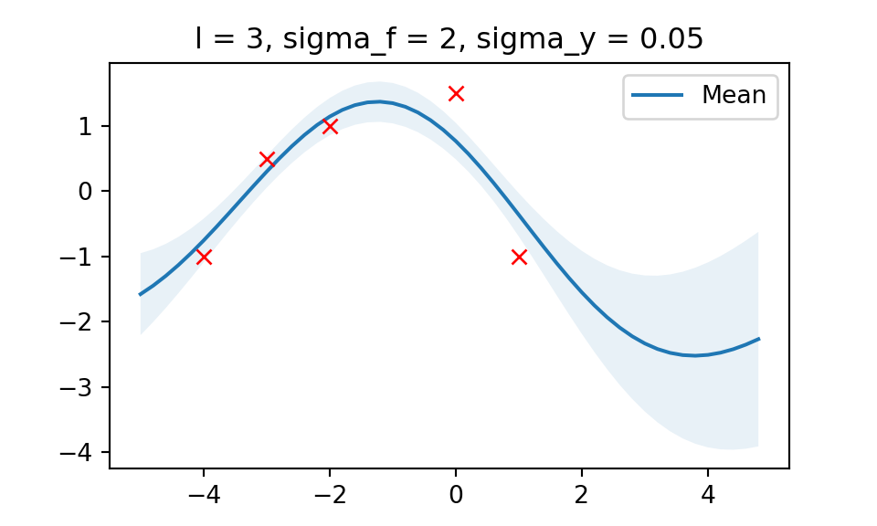

- It’s possible to optimize kernel’s parameters using  
  marginal likelihood

## Gaussian Processes - Bayesian Optimization

## Black box optimization

Given a function we would like to optimize WITHOUT knowing it’s gradient

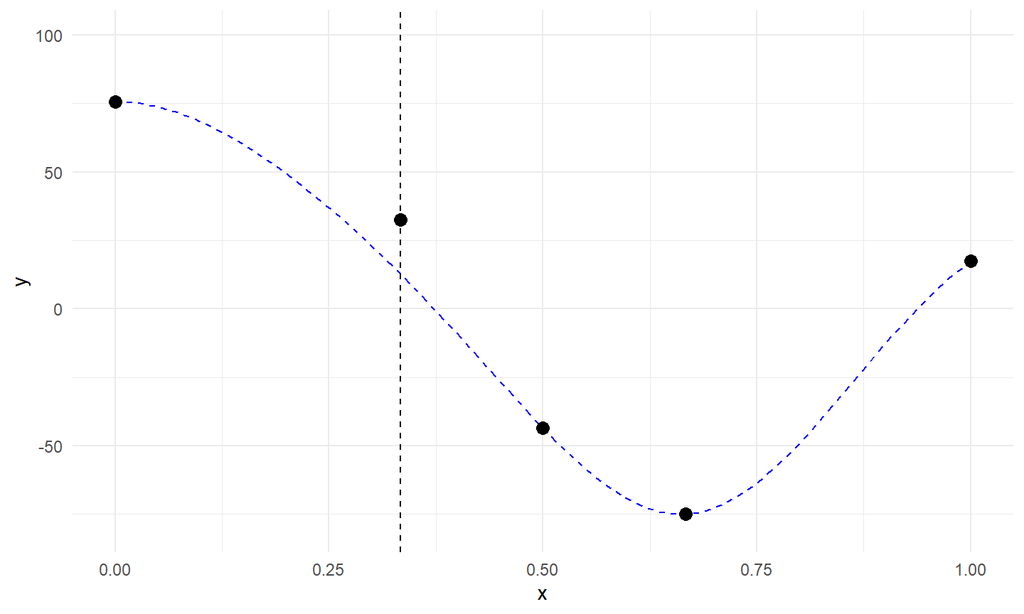

## GP Bayesian optimization:

- Black box optimization when no gradient exists
- It’s possible that grid search is expensive (i.e looking for oil)
- ML algorithms need that ! classical, Deep Learning…

**Algorithm:**  
** We take surrogate function - GP - easy to compute and gives CIs !  
** We train GP  
** We use acquisition function to suggest on new points to explore  
** Evaluate our function at acq’ function extremum - new point added  
** Continue till stopping criteria

## Bayesian Opt - round 1:

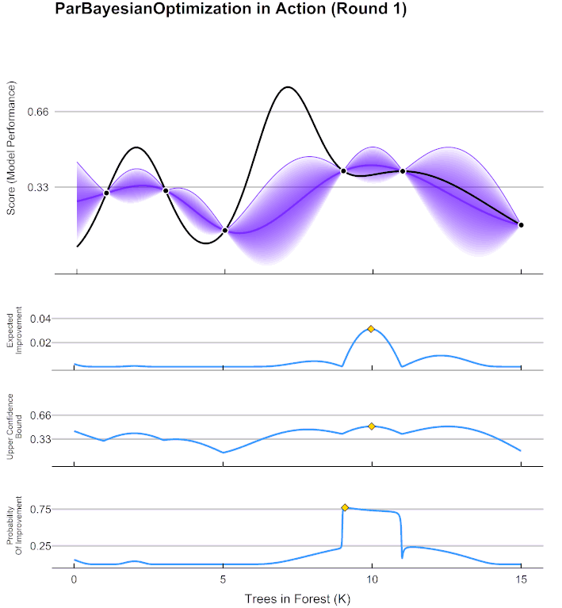

## Bayesian Opt - round 2:

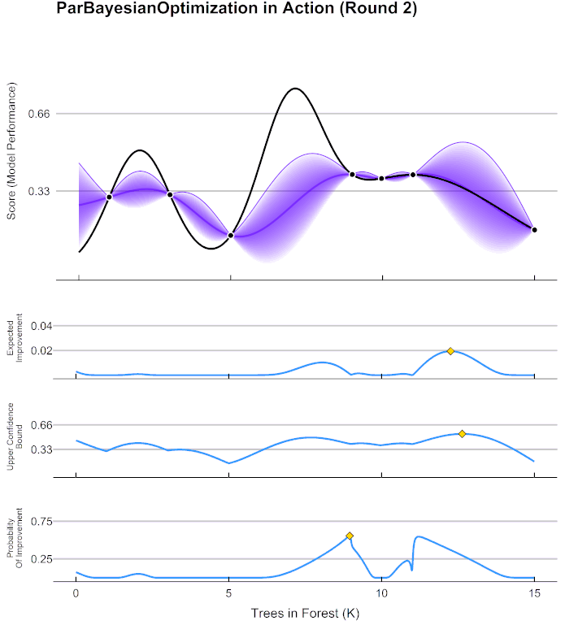

## Bayesian Opt - round 3:

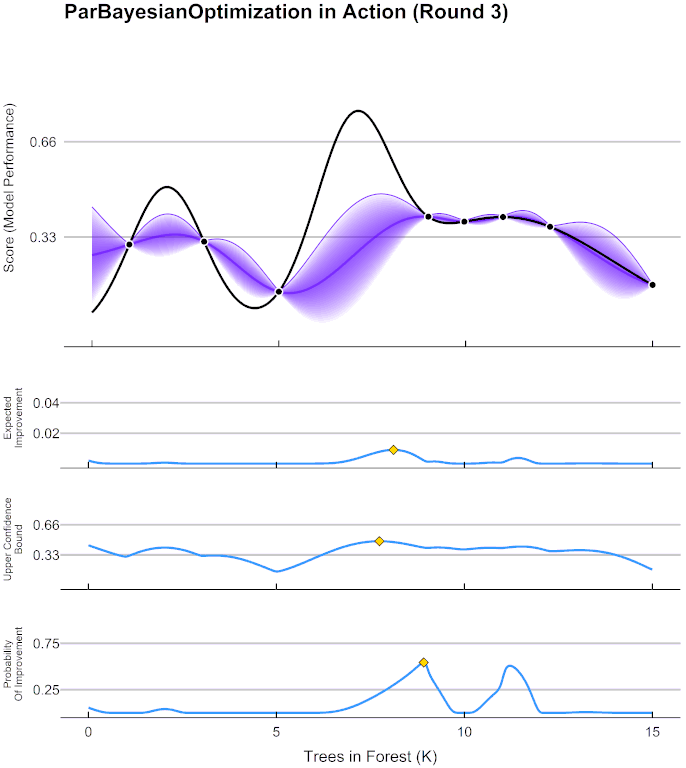

## Bayesian Opt - round 4:

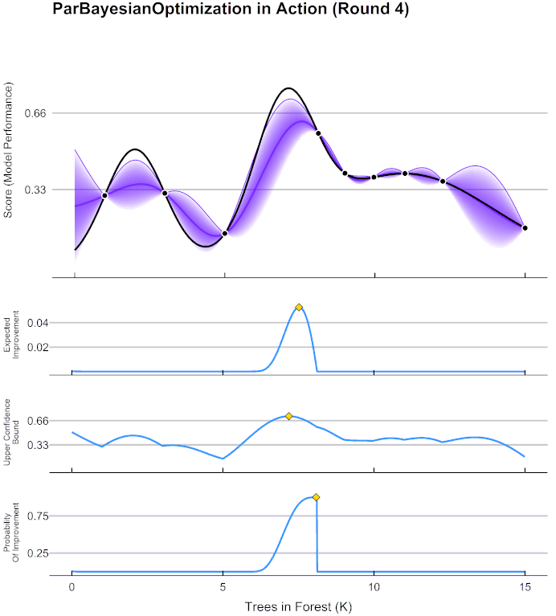

## Bayesian Opt - round 5:

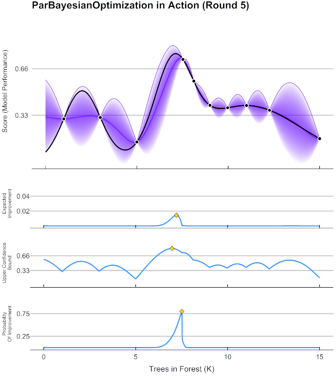

## Bayesian Opt - round 6:

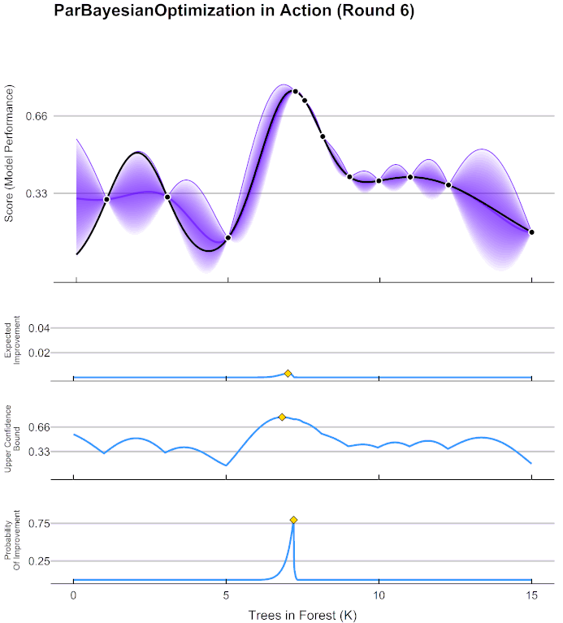

## Bayesian Opt - round 7:

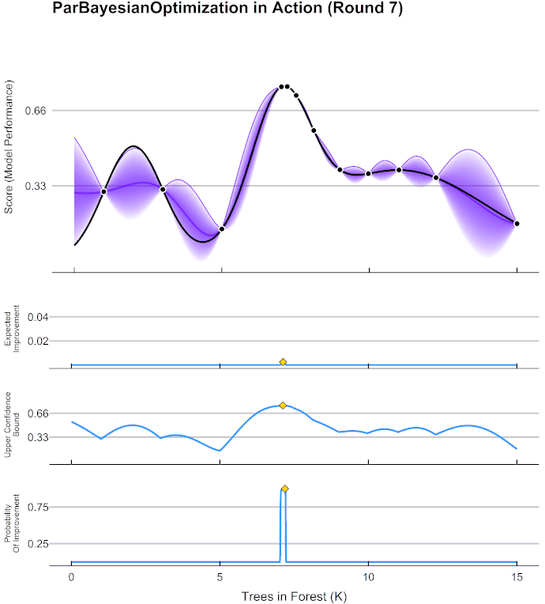

## Summary

## Summary

**Pros**  
- GPs are powerful and elegant ML method  
- We get a measure of (un)certainty of prediction - for free !  
- Works very good with regression with small training data sets

**Cons**  
- Matrix inversion \(\ O(n^3)\)  
- More involved in Classification tasks

## References:

1. C.E Rasmussen & C.K.I Williams : Gaussian Processes for Machine Learning, MIT Press 2006 http://www.gaussianprocess.org/gpml/chapters/RW.pdf
2. ParBayesianOptimization R package: https://github.com/AnotherSamWilson/ParBayesianOptimization
3. scikit-learn - Gaussian Processes:  
   https://scikit-learn.org/stable/modules/gaussian_process.html